# Preliminary Analysis of Loan Cancellation Data

## Use weighting that considers the imbalance

We use a weighted version of gbm to see if the imbalance in the training set has any impact.

```r
model_weights = ifelse(trainY == "X7",
                        (1/table(trainY)[1]) * 0.5,
                        (1/table(trainY)[2]) * 0.5)
set.seed(20180211)
gbm.tune.weighted = train(x=trainX,y=trainY,
                  method = "gbm",
                  metric = "ROC",
                  trControl = ctrl,
                  tuneGrid=grid,
                  weights = model_weights,
                  verbose=FALSE)


# Look at the tuning results
# Note that ROC was the performance criterion used to select the optimal model.

gbm.tune.weighted$bestTune
```

```
##   n.trees interaction.depth shrinkage n.minobsinnode
## 8      20                 2       0.1             20
```

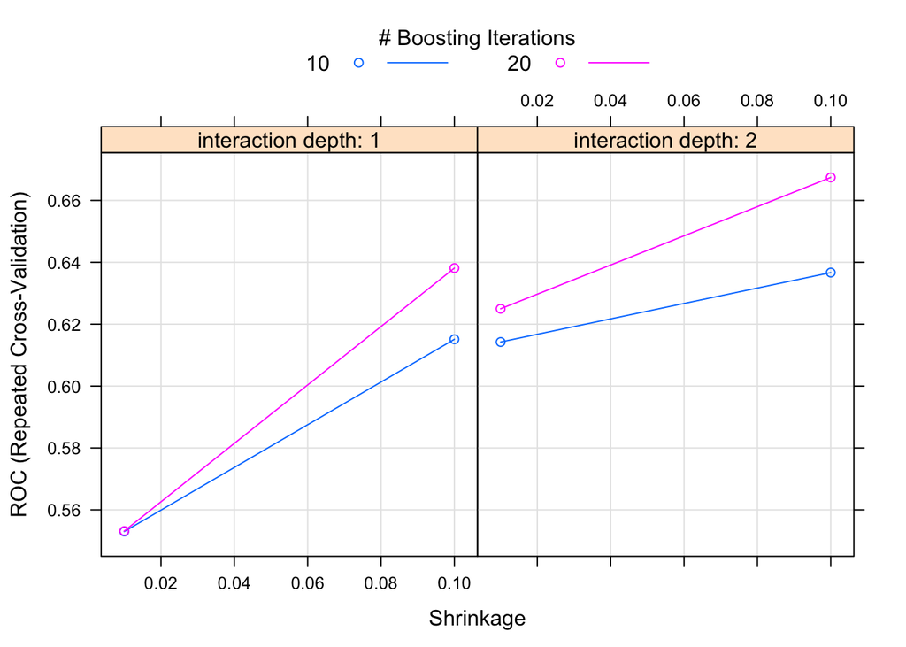

```r
plot(gbm.tune.weighted)         # Plot the performance of the training models
```

```r
res.weighted = gbm.tune.weighted$results
res.weighted
```

```
##   shrinkage interaction.depth n.minobsinnode n.trees       ROC      Sens
## 1      0.01                 1             20      10 0.5529999 0.1061611
## 5      0.10                 1             20      10 0.6151323 0.4000000
## 3      0.01                 2             20      10 0.6142479 0.4287915
## 7      0.10                 2             20      10 0.6366911 0.4322275
## 2      0.01                 1             20      20 0.5531512 0.1061611
## 6      0.10                 1             20      20 0.6381471 0.4101896
## 4      0.01                 2             20      20 0.6249932 0.4306872
## 8      0.10                 2             20      20 0.6674425 0.4408768
##        Spec       ROCSD     SensSD       SpecSD
## 1 0.9998215 0.006395098 0.01262557 0.0002661194
## 5 0.7839334 0.006501978 0.05319133 0.0420042044
## 3 0.7541208 0.008625063 0.01951562 0.0134722519
## 7 0.7603094 0.013732446 0.02652878 0.0183344946
## 2 0.9998215 0.006483312 0.01262557 0.0002661194
## 6 0.7839334 0.006925769 0.02204954 0.0214360347
## 4 0.7562035 0.011069378 0.01943724 0.0128535241
## 8 0.7704850 0.012593057 0.01561443 0.0076164320
```

```r
### GBM Model Predictions and Performance
# Make predictions using the test data set
gbm.pred.weighted = predict(gbm.tune.weighted,testX)

#Look at the confusion matrix
confusionMatrix(gbm.pred.weighted,testData$EnumListingStatus)
```

```
## Confusion Matrix and Statistics
##
##           Reference
## Prediction     X7     X6
##         X7  34433  34624
##         X6  41526 116613
##
##                Accuracy : 0.6648
##                  95% CI : (0.6629, 0.6668)
##     No Information Rate : 0.6657
##     P-Value [Acc > NIR] : 0.8028
##
##                   Kappa : 0.2296
##  Mcnemar's Test P-Value : <2e-16
##
##             Sensitivity : 0.4533
##             Specificity : 0.7711
##          Pos Pred Value : 0.4986
##          Neg Pred Value : 0.7374
##              Prevalence : 0.3343
##          Detection Rate : 0.1516
##    Detection Prevalence : 0.3040
##       Balanced Accuracy : 0.6122
##
##        'Positive' Class : X7
##
```

```r
#Draw the ROC curve
gbm.probs.weighted = predict(gbm.tune.weighted,testX,type="prob")
head(gbm.probs.weighted)
```

```
##          X7        X6
## 1 0.4617447 0.5382553
## 2 0.3242760 0.6757240
## 3 0.5227723 0.4772277
## 4 0.3568911 0.6431089
## 5 0.4814748 0.5185252
## 6 0.4223208 0.5776792
```

```r
gbm.ROC.weighted = roc(predictor=gbm.probs.weighted$X6,
               response=testData$EnumListingStatus)
gbm.ROC.weighted$auc
```

```
## Area under the curve: 0.6726
```

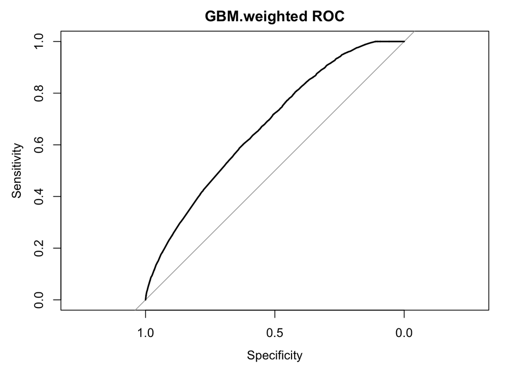

```r
#Area under the curve: 0.6656966
plot(gbm.ROC.weighted,main="GBM.weighted ROC")
```

And the histogram of the predictions

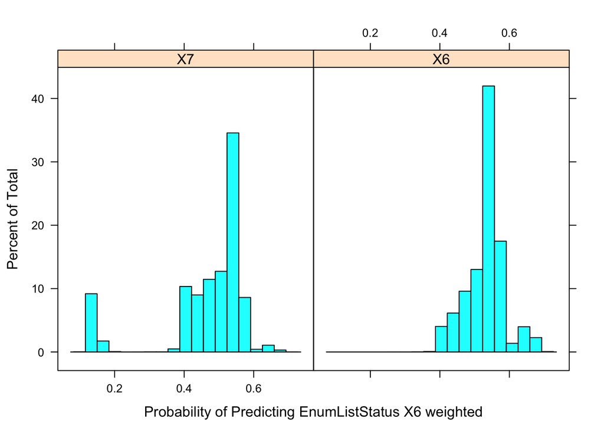

```r
# Plot the propability of prediction X6 conditional on the true class
histogram(~gbm.probs.weighted$X6|testData$EnumListingStatus,xlab="Probability of Predicting EnumListStatus X6 weighted")
```

```r
c(gbm.ROC$auc, gbm.ROC.weighted$auc)
```

```
## [1] 0.6677992 0.6726066
```

So we are getting a bit of performance by considering the imbalance in the examples

## Variable importance

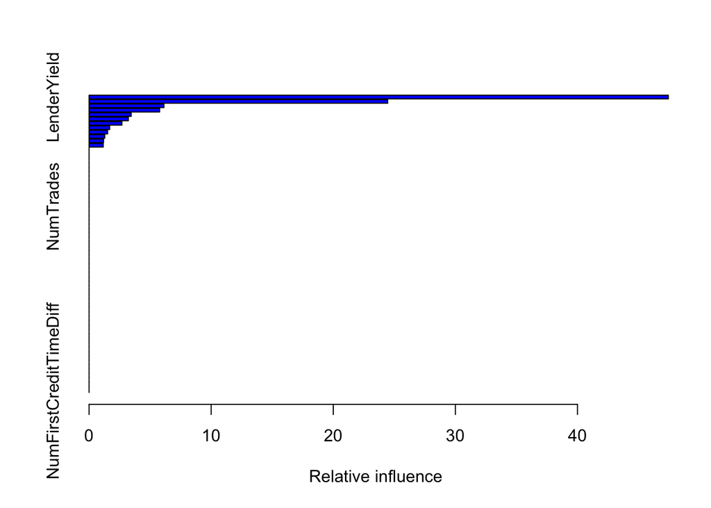

```
##                                                                   var
## LenderYield                                               LenderYield
## StrOccupation                                           StrOccupation
## NumPriorProsperLoans                             NumPriorProsperLoans
## NumLenderBorrowerSpread                       NumLenderBorrowerSpread
## DolLoanAmountRequested                         DolLoanAmountRequested
## EnumChannelCode                                       EnumChannelCode
## StrEmploymentStatus                               StrEmploymentStatus
## DolTotalBalanceInstallTradesReptd6 DolTotalBalanceInstallTradesReptd6
## DolMonthlyLoanPayment                           DolMonthlyLoanPayment
## NumListingTimeDiff                                 NumListingTimeDiff
## EnumListingCategory                               EnumListingCategory
## FracDebtToIncomeRatio                           FracDebtToIncomeRatio
## BoolPartialFundingApproved                 BoolPartialFundingApproved
## CreditGrade                                               CreditGrade
## BorrowerRate                                             BorrowerRate
## NumMonthsTerm                                           NumMonthsTerm
## FICOScore                                                   FICOScore
## ProsperScore                                             ProsperScore
## DolMonthlyIncome                                     DolMonthlyIncome
## BoolIncomeVerifiable                             BoolIncomeVerifiable
## NumMonthsEmployed                                   NumMonthsEmployed
## StrState                                                     StrState
## NumPriorProsperLoansActive                 NumPriorProsperLoansActive
## BoolIsLender                                             BoolIsLender
## BoolInGroup                                               BoolInGroup
## NumTrades                                                   NumTrades
## NumTradesOpened6                                     NumTradesOpened6
## NumTradesDelinqOrPastDue6                   NumTradesDelinqOrPastDue6
## NumOpenTradesDelinqOrPastDue6           NumOpenTradesDelinqOrPastDue6
## NumTradesCurr30DPDOrDerog6                 NumTradesCurr30DPDOrDerog6
## NumTradesEver90DPDOrDerog                   NumTradesEver90DPDOrDerog
## DolTotalBalanceAllOpenTrades6           DolTotalBalanceAllOpenTrades6
## DolTotalBalanceOnPublicRecords         DolTotalBalanceOnPublicRecords
## DolTotalPaymentAllOpenTrades6           DolTotalPaymentAllOpenTrades6
## AgeOldestTrade                                         AgeOldestTrade
## NumInquiries6MinusLastTwoWeeks         NumInquiries6MinusLastTwoWeeks
## PctTradesNeverDelinquent                     PctTradesNeverDelinquent
## NumBankcardTradesOpened12                   NumBankcardTradesOpened12
## DolTotalAvailBankcardCredit6             DolTotalAvailBankcardCredit6
```

[output cut: 83 more lines]

```
## PctBankcardUtil                     0.000000
## NumOpenRevolvingAccounts            0.000000
## DolRealEstateBalance                0.000000
## DolRevolvingBalance                 0.000000
## DolRealEstatePayment                0.000000
## NumTotalInquiries                   0.000000
## NumSatisfactoryAccounts             0.000000
## NumWasDelinquentDerog               0.000000
## NumDelinquenciesOver30Days          0.000000
## NumDelinquenciesOver60Days          0.000000
## BoolOwnsHome                        0.000000
## EnumLoanFractionalType              0.000000
## BoolEverWholeLoan                   0.000000
## BoolIsFractionalLoan                0.000000
## NumFirstCreditTimeDiff              0.000000
```

```r
summary(gbm.tune.weighted)
```

It seems that gbm considers only a small number of variables important, they are

```r
################################
### use reduced feature sets

gbm.tune.weighted.summary = summary(gbm.tune.weighted)
```

[figure not shown]

```r
(var.vec = c("EnumListingStatus",as.character(gbm.tune.weighted.summary$var[gbm.tune.weighted.summary$rel.inf > 0.1])))
```

```
##  [1] "EnumListingStatus"
##  [2] "LenderYield"
##  [3] "StrOccupation"
##  [4] "NumPriorProsperLoans"
##  [5] "NumLenderBorrowerSpread"
##  [6] "DolLoanAmountRequested"
##  [7] "EnumChannelCode"
##  [8] "StrEmploymentStatus"
##  [9] "DolTotalBalanceInstallTradesReptd6"
## [10] "DolMonthlyLoanPayment"
## [11] "NumListingTimeDiff"
## [12] "EnumListingCategory"
## [13] "FracDebtToIncomeRatio"
```

we are going to try using weighting and the reduced set of variable and see what happens

```r
trainData.reduced = trainData[, var.vec]
testData.reduced = testData[, var.vec]
trainX.reduced = trainData.reduced[,-1]        # Pull out the dependent variable
testX.reduced = testData.reduced[,-1]
trainY.reduced = trainData.reduced[,1]        # Pull out the dependent variable
testY.reduced = testData.reduced[,1]

# Set up training control
ctrl = trainControl(method = "repeatedcv",   # 10fold cross validation
                     number = 5,                            # do 5 repititions of cv
                     summaryFunction=twoClassSummary,   # Use AUC to pick the best model
                     classProbs=TRUE,
                     allowParallel = TRUE)

# Use the expand.grid to specify the search space
# Note that the default search grid selects multiple values of each tuning parameter

grid = expand.grid(interaction.depth=c(1,2), # Depth of variable interactions
                    n.trees=c(10,20),           # Num trees to fit
                    shrinkage=c(0.01,0.1),      # Try 2 values for learning rate
                    n.minobsinnode = 20)
#
set.seed(20180211)  # set the seed

# Set up to do parallel processing
registerDoParallel(4)       # Registrer a parallel backend for train
getDoParWorkers()
```

```
## [1] 4
```

```r
set.seed(20180211)
gbm.tune.reduced = train(x=trainX.reduced,y=trainY.reduced,
                  method = "gbm",
                  metric = "ROC",
                  trControl = ctrl,
                  tuneGrid=grid,
                   weights = model_weights,
                  verbose=FALSE)


# Look at the tuning results
# Note that ROC was the performance criterion used to select the optimal model.

gbm.tune.reduced$bestTune
```

```
##   n.trees interaction.depth shrinkage n.minobsinnode
## 8      20                 2       0.1             20
```

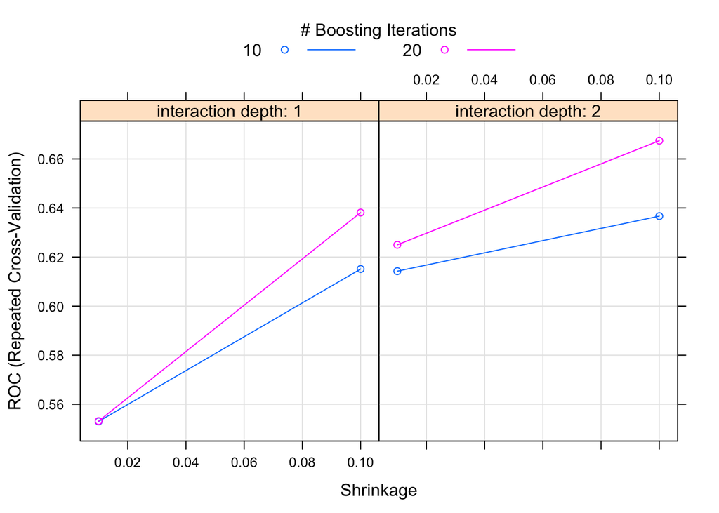

```r
plot(gbm.tune.reduced)          # Plot the performance of the training models
```

```r
res = gbm.tune.reduced$results
res
```

```
##   shrinkage interaction.depth n.minobsinnode n.trees       ROC      Sens
## 1      0.01                 1             20      10 0.5529999 0.1061611
## 5      0.10                 1             20      10 0.6151323 0.4000000
## 3      0.01                 2             20      10 0.6142479 0.4287915
## 7      0.10                 2             20      10 0.6366911 0.4322275
## 2      0.01                 1             20      20 0.5531512 0.1061611
## 6      0.10                 1             20      20 0.6381471 0.4101896
## 4      0.01                 2             20      20 0.6249932 0.4306872
## 8      0.10                 2             20      20 0.6674425 0.4408768
##        Spec       ROCSD     SensSD       SpecSD
## 1 0.9998215 0.006395098 0.01262557 0.0002661194
## 5 0.7839334 0.006501978 0.05319133 0.0420042044
## 3 0.7541208 0.008625063 0.01951562 0.0134722519
## 7 0.7603094 0.013732446 0.02652878 0.0183344946
## 2 0.9998215 0.006483312 0.01262557 0.0002661194
## 6 0.7839334 0.006925769 0.02204954 0.0214360347
## 4 0.7562035 0.011069378 0.01943724 0.0128535241
## 8 0.7704850 0.012593057 0.01561443 0.0076164320
```

```r
### GBM Model Predictions and Performance
# Make predictions using the test data set
gbm.pred.reduced = predict(gbm.tune.reduced,testX)

#Look at the confusion matrix
confusionMatrix(gbm.pred.reduced,testData.reduced$EnumListingStatus)
```

```
## Confusion Matrix and Statistics
##
##           Reference
## Prediction     X7     X6
##         X7      0      0
##         X6  75959 151237
##
##                Accuracy : 0.6657
##                  95% CI : (0.6637, 0.6676)
##     No Information Rate : 0.6657
##     P-Value [Acc > NIR] : 0.501
##
##                   Kappa : 0
##  Mcnemar's Test P-Value : <2e-16
##
##             Sensitivity : 0.0000
##             Specificity : 1.0000
##          Pos Pred Value :    NaN
##          Neg Pred Value : 0.6657
##              Prevalence : 0.3343
##          Detection Rate : 0.0000
##    Detection Prevalence : 0.0000
##       Balanced Accuracy : 0.5000
##
##        'Positive' Class : X7
##
```

```r
#Draw the ROC curve
gbm.probs.reduced = predict(gbm.tune.reduced,testX.reduced,type="prob")
head(gbm.probs.reduced)
```

```
##          X7        X6
## 1 0.4617447 0.5382553
## 2 0.3242760 0.6757240
## 3 0.5227723 0.4772277
## 4 0.3568911 0.6431089
## 5 0.4814748 0.5185252
## 6 0.4223208 0.5776792
```

```r
gbm.ROC.reduced = roc(predictor=gbm.probs.reduced$X6,
               response=testData.reduced$EnumListingStatus)
gbm.ROC.reduced$auc
```

```
## Area under the curve: 0.6726
```

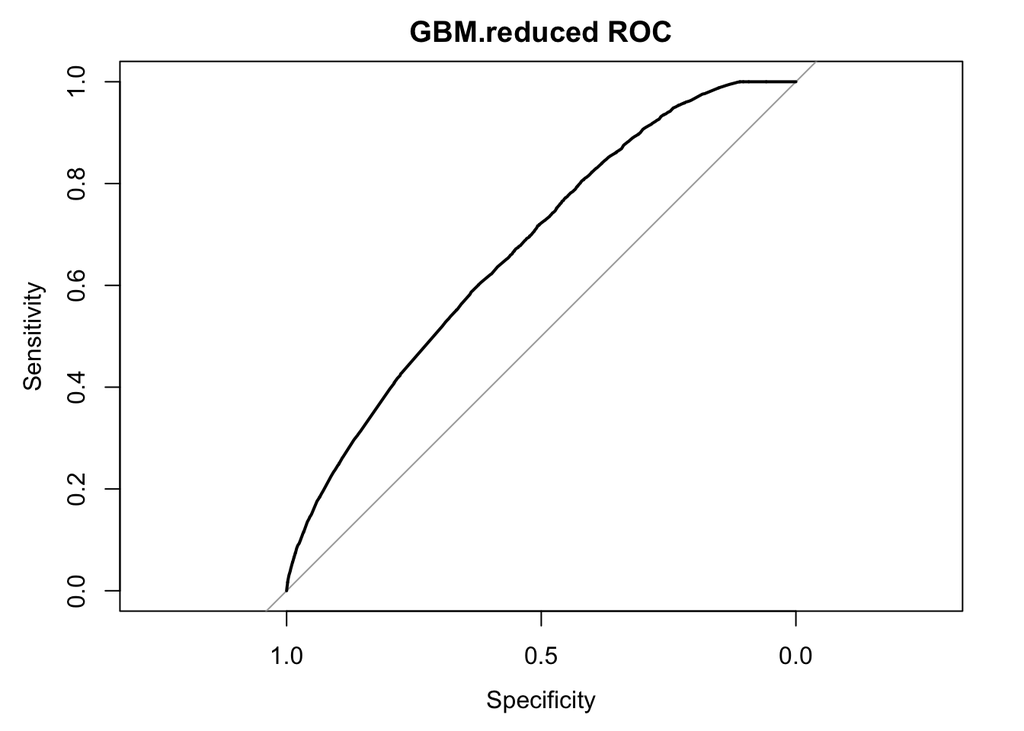

```r
#Area under the curve: 0.6676
plot(gbm.ROC.reduced,main="GBM.reduced ROC")
```

And the histogram

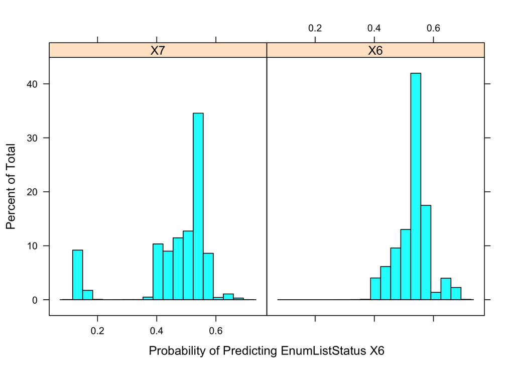

```r
# Plot the propability of prediction X6 conditional on the true class
histogram(~gbm.probs.reduced$X6|testData.reduced$EnumListingStatus,xlab="Probability of Predicting EnumListStatus X6")
```

Finally, the auc of three different methods

```r
c(gbm.ROC$auc, gbm.ROC.weighted$auc, gbm.ROC.reduced$auc)
```

```
## [1] 0.6677992 0.6726066 0.6726066
```

# Conclusion and future work

Working on a real-world data set like this has been an exciting and rewarding experience for me.